# ChatGPT 注册教程

oyjh

2023/5/6

**目录：**

- 前言
- 科学上网
- 注册和使用ChatGPT
- 辅助插件
- API接口
- 注意事项
- 镜像网站
- 联系方式

## 前言

**ChatGPT**，全称 聊天生成预训练转换器（**Chat** **G**enerative **P**re-trained **T**ransformer），是OpenAI公司（https://openai.com/）于2022年11月30日推出的人工智能聊天机器人程序，该程序使用基于GPT-3.5、GPT-4架构的大型语言模型并以强化学习训练。ChatGPT目前仍以文字方式交互，而除了可以用人类自然对话方式来交互，还可以用于甚为复杂的语言工作，包括自动生成文本、自动问答、自动摘要等多种任务。如：在自动文本生成方面，ChatGPT可以根据输入的文本自动生成类似的文本（剧本、歌曲、企划等），在自动问答方面，ChatGPT可以根据输入的问题自动生成答，还有编写和调试计算机程序的能力。

2023年年初，ChatGPT在全球火爆，掀起了全球人工智能大型语言模型（LLM）的竞赛狂潮，微软，谷歌等互联网巨头相继加入赛道，国内的许多头部企业，如百度，阿里等也陆续推出了自己的语言模型，在这场“第四次产业革命”的浪潮中，谁若跟不上时代的步伐，必将被时代淘汰。

我是在2022年12月6日开始注册使用ChatGPT的，注册成功后我立马将其投入到了日常的工作学习中，ChatGPT的强大令人震惊，它的使用极大地提高了我的工作和学习效率，举例来说，以往需要花费很多时间（甚至是一整天时间）来解决的程序运行中出现的bug，现在用ChatGPT可能只需要几秒便能得到准确的答案，它的文本生成能力同样强大，能够快速准确地翻译英文语句，对论文进行润色（可以以指定的风格进行润色），只要输入合适的指令，它几乎能生成任何人们想要的文本。

时至今日，身边仍有许多朋友不太清楚如何注册并使用ChatGPT（它的注册过程确实繁琐，并且审核确实越来越严格），作为第一批使用ChatGPT的用户，我在这方面积累了一定的使 用经验，“独乐乐不如众乐乐”，在这里我写了一个简单的教程，将自己的使用（注册）经验分享给大家，希望能对大家有所帮助。

## 科学上网

ChatGPT目前还无法在国内的网络环境下使用，因此要在国内使用的话我们需要挂上VPN，使用国外的ip注册并使用ChatGPT，也就是俗称的“翻墙”。 目前市面上能够用于翻墙的软件有很多，我在这里列出几个：

- [Qv2ray](https://github.com/Qv2ray/Qv2ray/releases)
- [Clash](https://github.com/Fndroid/clash_for_windows_pkg/releases)
- [Greenhub](https://greenhubtx.ga/?utm_source=desktop&utm_medium=click&utm_campaign=about)
- [TLY](https://tly.com/zh/app.php)
- [cloudyu](https://cloudyu.top/#/login)

在上面的软件中，**Qv2ray**和**Clash**是最安全，稳定，专业的，我自己的使用的也是Qv2ray，但是它的安装过程和其他的“傻瓜式”软件相比略显繁琐，总的来说就是要先装一个软件，再装软件的核心，验证通过后再添加机场订阅链接(推荐一个机场：https://shuttle.gt-in.com/clientarea.php)，然后即可选择自己想要代理的节点。由于VPN的使用并不是本教程的核心内容，在这里我推荐一个网上的教程供大家参考，（[点击这里](https://sites.google.com/view/honven/%E9%A6%96%E9%A1%B5/qv2ray%E5%BF%AB%E9%80%9F%E4%B8%8A%E6%89%8B%E7%AE%80%E5%8D%95%E4%BD%BF%E7%94%A8%E6%95%99%E7%A8%8B)）。

配置好VPN后可以尝试打开Chrome浏览器使用Google搜索感兴趣的内容，如果能够正常使用则说明VPN配置成功。

## 注册和使用ChatGPT

**这一节是本教程的主要内容，请务必仔细阅读。**

1. **进入OpenAI的官网注册ChatGPT账号**  
   OpenAI官网：https://openai.com/  
   进入后找到并点击*Try ChatGPT*,随后点击*Sign up*

[figure not shown]

[figure not shown]

2. **输入注册邮箱号，并按照要求设置密码**

   *使用qq邮箱可能会导致无法注册，建议使用163邮箱或谷歌邮箱等其他邮箱。*

[figure not shown]

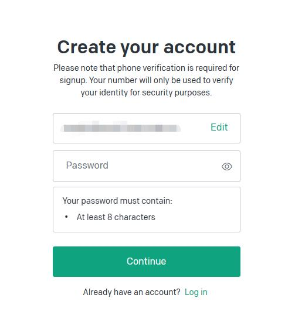

密码设置成功后点击*确定*，会让你填姓名和出生日期，这个随便填就行，一般不会出错

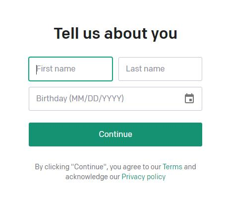

3. **验证手机号**  
   **注意，这是本教程中最核心和关键的步骤，绝大多数人注册都是卡在了这一步。**  
   ChatGPT在使用之前必须先用国外的手机号注册，注意，不是随便哪个国家都可以，而是要用OpenAI提供服务的国家，ChatGPT官方并没有列出哪些国家能使用，但是根据网友实测，建议使用以下地区的电话进行验证：
- 美国：United States
- 加拿大：Canada
- 英国：United Kingdom
- 澳大利亚：Australia
- 意大利：Italy
- 法国：France
- 德国：Germany
- 荷兰：Netherlands
- 芬兰：Finland
- 瑞典：Sweden
- 丹麦：Denmark
- 挪威：Norway
- 日本：Japan
- 新加坡：Singapore

[figure not shown]

选择完国家后，我们需要该国家的手机号，如何找到呢？我们可以去一些网站购买虚拟手机号用于接收验证码，这里我推荐一个网站**sms-activate**：https://sms-activate.org/cn  
进入该网站后在左侧栏选择你需要接收验证码的**应用**以及虚拟手机号所在的**国家**

[figure not shown]

然后根据你选择的国家旁边标注的价格进行充值（这个网站是由俄罗斯人开发的，因此货币都显示为卢布），点击右上角的 *充值* 按钮，可以使用支付宝进行方便快捷的支付

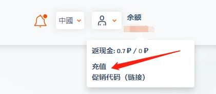

充值完之后，点击购物车图标进行购买

[figure not shown]

购买成功后会来到短信激活界面，在这里会给出一个你所选国家的虚拟号码，然后将这个号码复制到ChatGPT需要输入手机号的界面，点击*Send code via SMS*

[figure not shown]

[figure not shown]

这个时候，有极大概率出现短信发送不出的情况，如下图所示：

[figure not shown]

**这个时候不用慌！只需要更改VPN的节点即可，就是不停地变化ip地址，然后刷新注册界面重试，直到能够发出短信为止。**  
发出短信后，会在sms-activate网站地激活界面收到验证码，再将验证码输入到openAI的注册界面即可。

[figure not shown]

4. **使用ChatGPT**  
   填完验证码后如无意外即可顺利进入ChatGPT界面，在搜索框直接输入问题即可提问

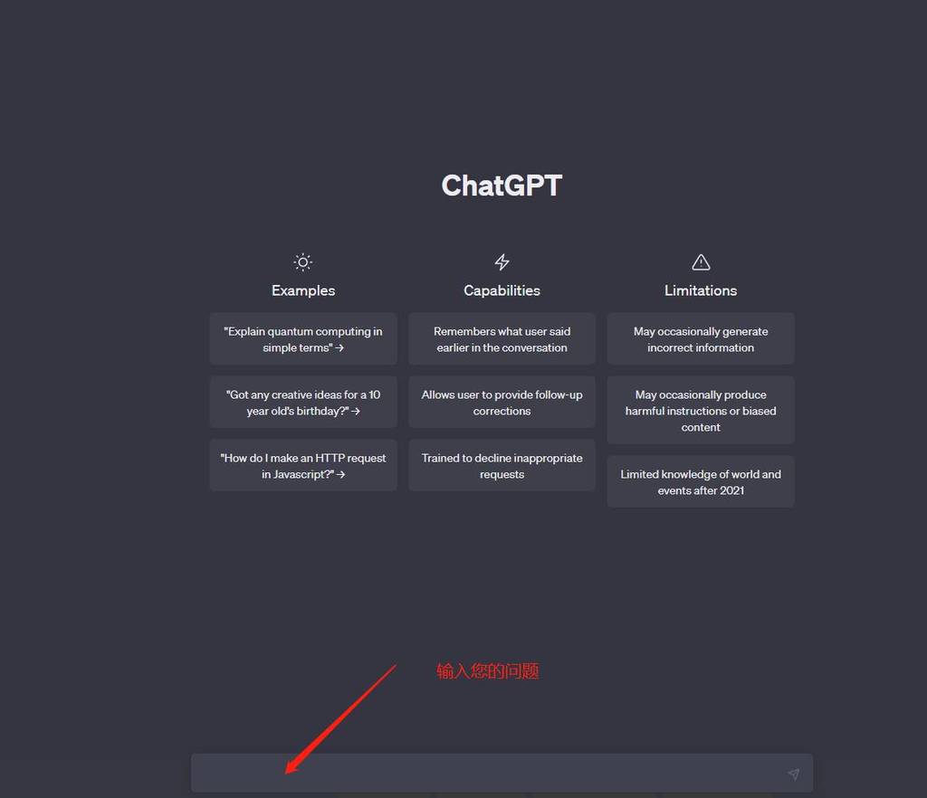

   还可以根据个人爱好在左下角 *setting* 处更改主题颜色，（我个人一般都会改成深色）

**至此，chatGPT的注册终于大功告成！**

*（免费版的ChatGPT是基于GPT-3.5模型训练的，要想升级到GPT-4获得更佳的使用体验需要充值Plus会员）*

## 辅助插件

ChatGPT火爆后许多相关的浏览器插件也被迅速开发出来，这里我以谷歌历览器为例，推荐几款常用的chatGPT插件。不熟悉浏览器插件使用方法的可以先去看一下[官方教程](https://support.google.com/chromebook/answer/2588006?hl=zh-Hans)

[output not shown]

## API

API接口指的是应用程序接口（**Application Programming Interface**），是一种用于软件系统之间进行交互的协议。API接口可以使不同的软件系统之间相互通信和交换数据，从而实现各种复杂的功能。  
ChatGPT同样也提供API接口，获取API的方法如下：  
进入https://platform.openai.com/overview，先在右上角登录ChatGPT账号，然后选择右上角的view API keys，然后创建自己的key。  
**注意**：每个API key只显示一次，因此要及时保存，且不能将key泄露出去，否则可能会危及账号安全。

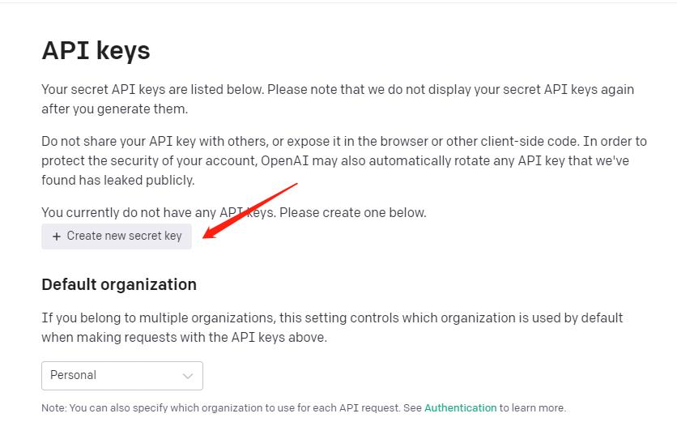

## 注意事项

ChatGPT有时可能会被封禁，导致无法使用，有网友整理了如下的封禁原因：

1. 批量注册：通过相同或类似IP地址批量注册的账号
2. IP地址：经常切换节点或账号同时挂载了多个地区的IP（共享号），或者频繁尝试通过不支持的区域访问（如香港）
3. API滥用：在不支持的地区使用API，或者利用多个账号获取API并对外提供服务
4. 聊天全是中文：不会直接封，但会上调风控级别，增加封号概率
5. 账号风险：注册时使用接码平台的电话号码，或者用于付款的银行卡存在风险
6. 账号登录：同一台机子先后登录不同账号，增加封号概率

**但是，大都数情况下封的都是ip而不是账号!（本人就遇到过这种情况） 这时只需将浏览器上与OpenAI有关的Cookies删除，并更换节点再重新登录ChatGPT即可。**  
[如何删除浏览器中的cookie（以chrome为例）](https://support.google.com/chrome/answer/95647?hl=zh-Hans&co=GENIE.Platform%3DDesktop#zippy=%2C%E5%88%A0%E9%99%A4%E6%9D%A5%E8%87%AA%E6%9F%90%E4%B8%AA%E7%BD%91%E7%AB%99%E7%9A%84-cookie)

## 镜像网站

镜像网站（**mirror website**）指的是一个网站的内容被复制到一个或多个其他服务器上，以便在多个地点提供相同的内容。镜像网站通常用于提高访问速度、增加可靠性、减轻源网站的负载压力等方面。  
当没有ChatGPT账号或者无法使用VPN时，可以尝试使用ChatGPT的镜像网站。 Github上有人总结了chatGPT相关的免费镜像网站合集：https://github.com/LiLittleCat/awesome-free-chatgpt  
此外某些浏览器插件也能提供类似的功能，例如[Wetab](https://chrome.google.com/webstore/detail/wetab-%E6%96%B0%E6%A0%87%E7%AD%BE%E9%A1%B5%E5%B7%B2%E6%95%B4%E5%90%88chatgpt/aikflfpejipbpjdlfabpgclhblkpaafo?hl=zh-CN)

## 联系方式

在本教程中遇到任何问题请联系 oyjh417701@163.com

May 6 CST 2023  
Copyright (c) 2023 OYJH  
All Rights Reserved.